# Администрирование сетевых подсистем

Лабораторная работа №9

Тойчубекова Асель Нурлановна

kulyabov-ds@rudn.ru

Российский университет дружбы народов

2025-11-01

# Информация

## Докладчик

- Тойчубекова Асель Нурлановна
- Студент 3 курса
- факультет физико-математических и естественных наук
- Российский университет дружбы народов им. П. Лумумбы
- 1032235033@rudn.ru

# Цель работы

## Цель работы

Целью лабораторной работы является приобретение практических навыков по установке и простейшему конфигурированию POP3/IMAP-сервера.

# Задание

## Задание

1. Установите на виртуальной машине server Dovecot и Telnet для дальнейшей проверки корректности работы почтового сервера.
2. Настройте Dovecot.
3. Установите на виртуальной машине client программу для чтения почты Evolution и настройте её для манипуляций с почтой вашего пользователя. Проверьте корректность работы почтового сервера как с виртуальной машины server, так и с виртуальной машины client.
4. Измените скрипт для Vagrant, фиксирующий действия по установке и настройке Postfix и Dovecote во внутреннем окружении виртуальной машины server, создайте скрипт для Vagrant, фиксирующий действия по установке Evolution во внутреннем окружении виртуальной машины client. Соответствующим образом внесите изменения в Vagrantfile.

# Теоретическое введение

## Теоретическое введение

Dovecot — это современный и надёжный почтовый сервер (Mail Delivery Agent, MDA), обеспечивающий пользователям доступ к электронной почте по протоколам POP3 и IMAP. Он используется совместно с SMTP-сервером (например, Postfix) для получения и хранения почтовых сообщений, а также для обеспечения их безопасности с помощью протокола TLS.

## Теоретическое введение

Dovecot поддерживает два основных формата хранения почтовых сообщений: mbox и Maildir. В формате mbox все письма пользователя хранятся в одном общем текстовом файле. Такой подход требует применения механизмов блокировки файла, чтобы избежать повреждения данных при одновременном доступе нескольких процессов.

## Теоретическое введение

Формат Maildir, напротив, хранит каждое сообщение в отдельном файле с уникальным именем, что повышает надёжность и производительность системы. В этом случае блокировка и целостность обеспечиваются средствами файловой системы, а каждая папка почты представлена отдельным каталогом.

## Теоретическое введение

Основные файлы конфигурации Dovecot располагаются в каталоге /etc/dovecot/, включая основной конфигурационный файл dovecot.conf и дополнительные файлы настроек в подкаталоге conf.d. Сертификаты безопасности, необходимые для шифрования соединений, хранятся в каталоге /etc/pki/dovecot/.

При совместной работе SMTP-сервера и POP3/IMAP-сервера возможны два варианта организации взаимодействия:

- Оба сервера работают параллельно и имеют общий доступ к почтовым ящикам пользователей;
- SMTP-сервер передаёт функции работы с ящиками Dovecot’у, и только он управляет почтой пользователей.

# Выполнение лабораторной работы

## Установка Dovecot

Для начала лабораторной работы запустим вм server, войдем под нашим пользователем и откроем терминал. Перейдем в режим суперпользователя и установим необходимые для работы пакеты.

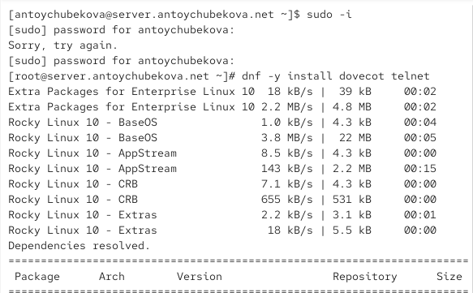

Установка необходимых пакет

## Настройка dovecot

В конфигурационном файле /etc/dovecot/dovecot.conf пропишем список почтовых протоколов, по которым разрешено работать Dovecot: protocols = imap pop3.

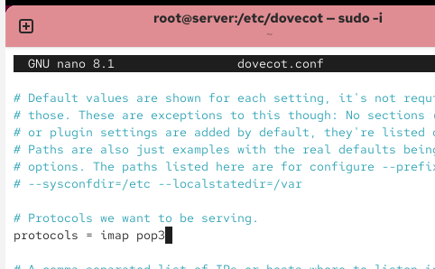

Список почтовых протоколов, по которым разрешено работать

## Настройка dovecot

В конфигурационном файле /etc/dovecot/conf.d/10-auth.conf проверим, что указан метод аутентификации plain: auth_mechanisms = plain.

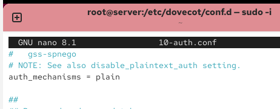

Метод аутентификации plain

## Настройка dovecot

В конфигурационном файле /etc/dovecot/conf.d/auth-system.conf.ext проверим, что для поиска пользователей и их паролей используется pam и файл passwd.

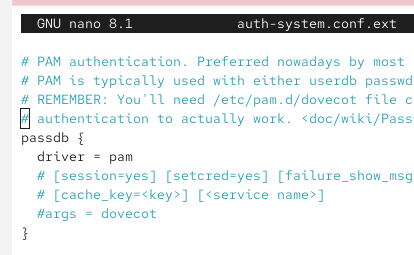

Поиск пользователей и их паролей

## Настройка dovecot

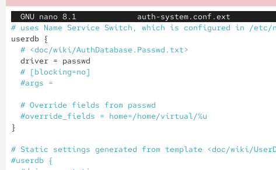

Поиск пользователей и их паролей

## Настройка dovecot

В конфигурационном файле /etc/dovecot/conf.d/10-mail.conf настроим месторасположение почтовых ящиков пользователей.

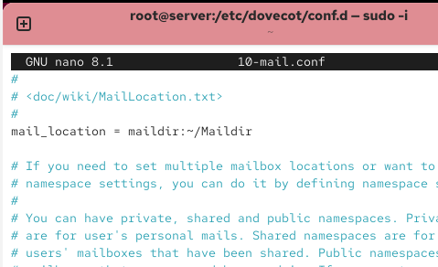

Местоположение почтовых ящиков пользователей

## Настройка dovecot

В Postfix зададим каталог для доставки почты.

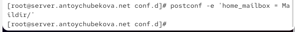

Каталог для доставки почты

## Настройка dovecot

Сконфигурируем межсетевой экран, разрешив работать службам протоколов POP3 и IMAP.

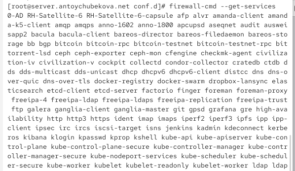

Настройка межсетевого экрана

## Настройка dovecot

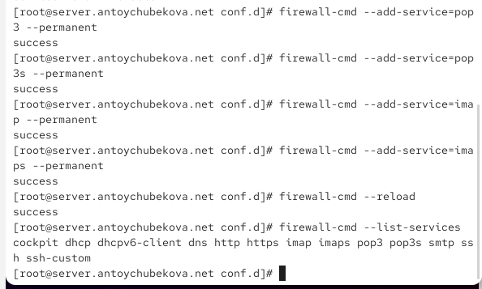

Настройка межсетевого экрана

## Настройка dovecot

Восстановим контекст безопасности в SELinux.

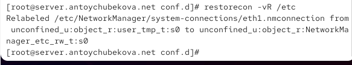

Восстановление контекста безопасности в SELinux

## Настройка dovecot

Перезапустим Postfix и запустим Dovecot.

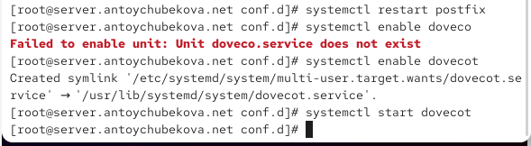

Перезапуск Postfix, запуск Dovecot

## Проверка работы Dovecot

На дополнительном терминале виртуальной машины server запустим мониторинг работы почтовой службы.

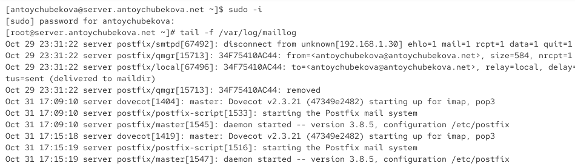

Мониторинг работы почтовой службы

## Проверка работы Dovecot

На терминале сервера просмотрим имеющейся почты используя MAIL=~/Maildir mail. Мы видим, что почта пока пустая, никаких писем нет.

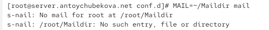

Просмотр почты

## Проверка работы Dovecot

Для просмотра mailbox пользователя на сервере на терминале с правами суперпользователя используем команду: doveadm mailbox list -u antoychubekova. Мы видим, что у нашего пользователя antoychubekova есть почтовый ящик INBOX.

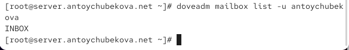

Просмотр mailbox

## Проверка работы Dovecot

На виртуальной машине client войдем под нашим пользователем и откроем терминал. Перейдем в режим суперпользователя. Далее установим почтовый клиент.

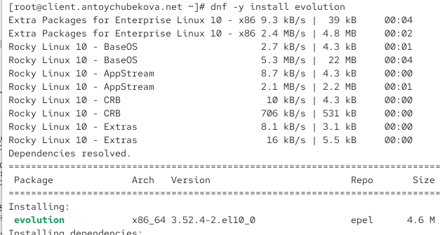

Запуск клиент и установка почтового клиента

## Проверка работы Dovecot

Запустим и настроим почтовый клиент Evolution. В окне настройки учётной записи почты укажем имя, адрес почты в виде antoychubekova@antoychubekova.net, введtv пароль пользователя, нажмем «Продолжить», затем нажмем «Настроить вручную».

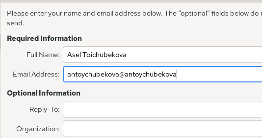

Настройка почтового клиента Evolution

## Проверка работы Dovecot

В качестве IMAP-сервера для входящих сообщений и SMTP-сервера для исходящих сообщений пропишем mail.antoychubekova.net, в качестве пользователя для входящих и исходящих сообщений укажем antoychubekova. Проверим номера портов: для IMAP — порт 143, для SMTP — порт 25. Проверим настройки SSL и метода аутентификации: для IMAP — STARTTLS, аутентификация по обычному паролю, для SMTP — без аутентификации, аутентификация — «Без аутентификации».

## Проверка работы Dovecot

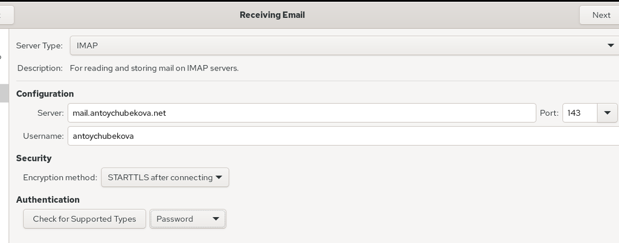

Настройка почтового клиента Evolution

## Проверка работы Dovecot

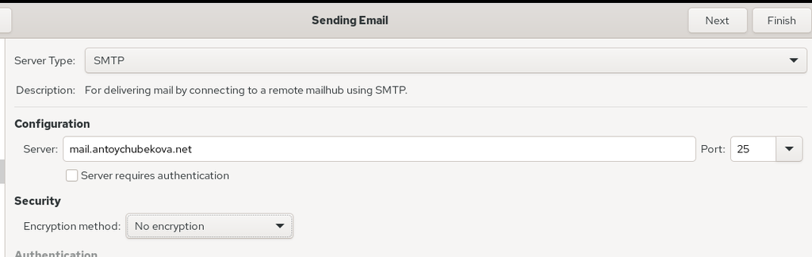

Настройка почтового клиента Evolution

## Проверка работы Dovecot

Просмотрев итоговые настройки сохраним изменения.

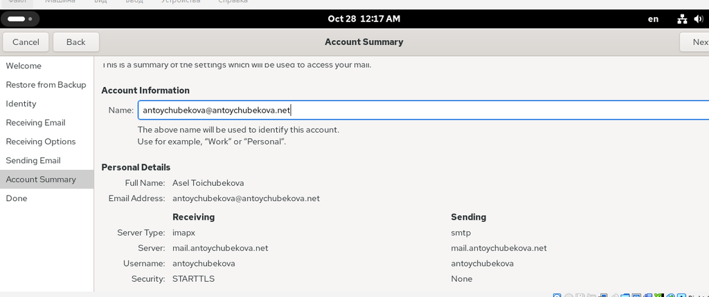

Сохранение настройки почтового клиента Evolution

## Проверка работы Dovecot

Из почтового клиента отправим себе несколько тестовых писем.

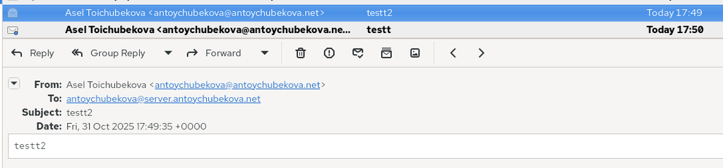

Отправка текстового письма

## Проверка работы Dovecot

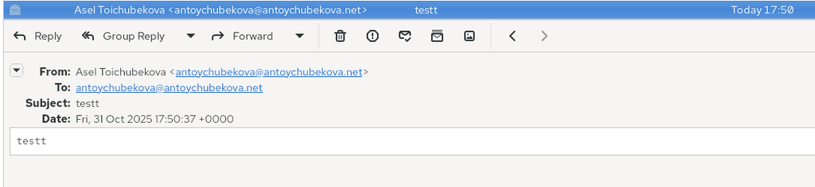

Отправка текстового письма

## Проверка работы Dovecot

Убедимся, что они доставлены. Для этого просмотрим сообщения при мониторинге почтовой службы. Мы видим, что отображается процесс приёма и доставки писем. После соединения клиента client.antoychubekova.net сервер Postfix принимает сообщение, обрабатывает его и сохраняет в почтовом ящике пользователя (Maildir). Каждое сообщение получает уникальный идентификатор (ID) и после успешной доставки удаляется из очереди.Dovecot обеспечивает доступ пользователя к полученным письмам по протоколам POP3/IMAP. Все строки с delivered to maildir подтверждают успешную доставку сообщений.

## Проверка работы Dovecot

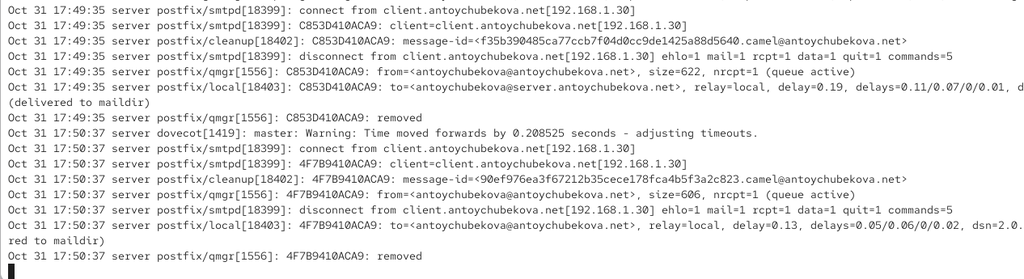

Мониторинг почтовой службы

## Проверка работы Dovecot

Также посмотрим сами письма в Maildir, используя mail. Мы видим, что выводятся все письма отправленные клиентом, а также их содержание.

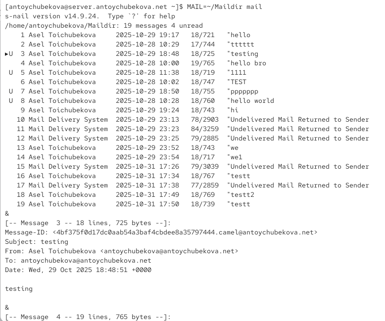

Просмотр почты

## Проверка работы Dovecot

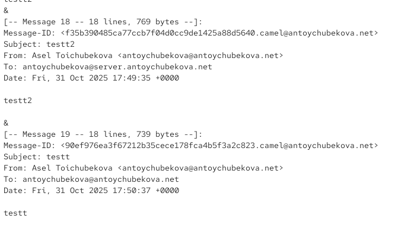

Просмотр почты

## Проверка работы Dovecot

Также можем посмотреть почту через doveadm. Мы видим, что у нашего пользователя есть почтовый ящик INBOX и мы можем посмотреть его содержание. В содержании мы видим, содержание всех отправленных до писем.

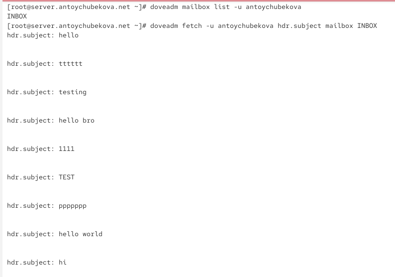

Просмотр почты

## Проверка работы Dovecot

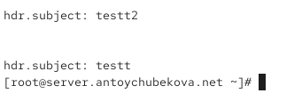

Просмотр почты

## Проверка работы Dovecot

Проверим работу почтовой службы, используя на сервере протокол Telnet. Подключимся с помощью протокола Telnet к почтовому серверу по протоколу POP3 (через порт 110), введем свой логин для подключения и пароль. Мы видим, что все успешно подключилось.

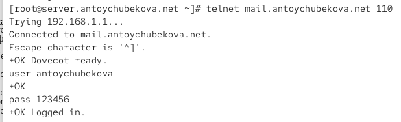

Подключение Telnet к почтовому серверу

## Проверка работы Dovecot

С помощью команды list получим список писем. Мы видим, что у нас 19 писем и нам вывелся размер и номер каждого письма.

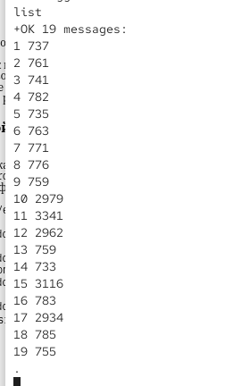

Список писем